# Lab 1 - Intro to R and RStudio

Key

Week 1

## Lab report

#### Exercise 1:

```r
arbuthnot$girls
```

#### Exercise 2:

As you can see in the plot below, the number of girls steadily rose over time, though there was a period from 1640 to 1660 when there was a notable drop in baptisms.

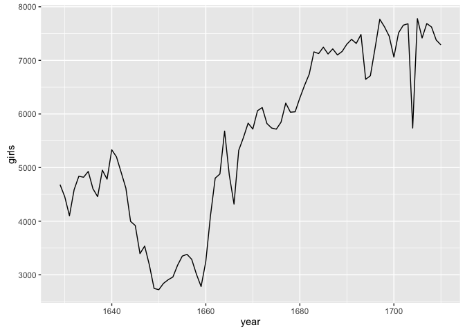

```r
qplot(x = year, y = girls, data = arbuthnot, geom = "line")
```

#### Exercise 3:

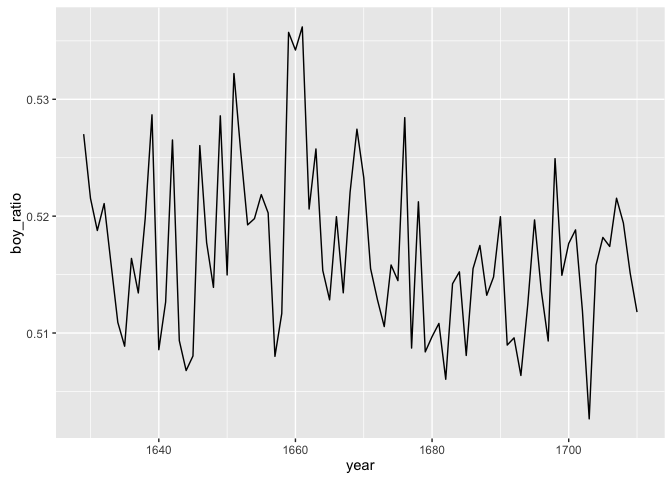

The plot above shows that the proportion of boys varied year to year but stayed consistently above 0.5. It should be noted that though the counts appear highly variable year to year, the y-axis shows that the changes are actually quite small.

### On your own:

#### 1:

```r
dim(present)
```

```
## [1] 63  3
```

```r
names(present)
```

```
## [1] "year"  "boys"  "girls"
```

#### 2:

These counts are several orders of magnitude larger than those in `arbuthnot`.

#### 3:

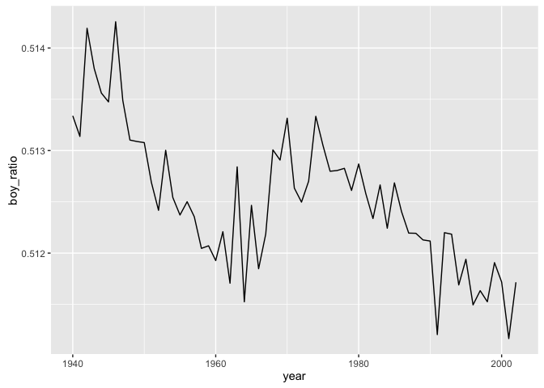

```r
present <- mutate(present, total = boys + girls)
present <- mutate(present, boy_ratio = boys / total)
qplot(x = year, y = boy_ratio, data = present, geom = "line")
```

The plot above shows that there as been a gradual decline in proportion of births that are boys, with the exception of an uptick in the 1960s. Again, the scale on the y-axes is quite zoomed in, so the variation is exaggerated. Similar to `arbuthnot`, the proportion is consistently above 0.5.

#### 4:

```r
arrange(present, desc(total))
```

```
##    year    boys   girls   total boy_ratio
## 1  1961 2186274 2082052 4268326 0.5122088
## 2  1960 2179708 2078142 4257850 0.5119269
## 3  1957 2179960 2074824 4254784 0.5123550
## 4  1959 2173638 2071158 4244796 0.5120713
## 5  1958 2152546 2051266 4203812 0.5120462
## 6  1962 2132466 2034896 4167362 0.5117064
## 7  1956 2133588 2029502 4163090 0.5125011
## 8  1990 2129495 2028717 4158212 0.5121179
## 9  1991 2101518 2009389 4110907 0.5112054
## 10 1963 2101632 1996388 4098020 0.5128408
## 11 1992 2082097 1982917 4065014 0.5121992
## 12 2000 2076969 1981845 4058814 0.5117182
## 13 1955 2073719 1973576 4047295 0.5123716
## 14 1989 2069490 1971468 4040958 0.5121286
```

[output cut: 49 more lines]

The sorted list shows that the 1961 is the year with the greatest number of total births in the US.